# Yusha Example

Karl Tayeb

2023-01-09

```r
library(targets)
library(dplyr)
library(logisticsusie)
```

## 0.1 Description

**Data**: Single cell RNA seq of (pancreatic?) cancer tumors. Gene lists derived from matrix factorization loadings.

**Gene sets**: The gene sets used in this example were provided by Yusha, they appear to be some filtered set of MSigDBs C2 genesets. Note that gene sets are reorded by the strength of the marginal enrichment via Fisher’s exact test. So that when we read `top_feature` in the tables below, we can quickly see how the marginal enrichments for selected gene sets stack up.

This is an example where logistic SuSiE essentially fit the null model. It has spurred exploration of different variational approximations. While we have been able to develop new approximations that improve the performance of logistic SuSiE in simulation, this examples is still troublesome.

## 0.2 All Gene Sets

```r
fits <- tar_read(yusha_fits)
```

```
## unable to deduce timezone name from 'America/Chicago'
```

```r
fits %>%
    mutate(converged = if_else(is.null(fit$converged), NA, fit$converged[1]))
```

```
## # A tibble: 11 × 6
## # Rowwise:
##    fit_method       fit_fun          fit_args     fit_sym fit          converged
##    <chr>            <chr>            <list>       <list>  <list>       <lgl>
##  1 vb_ser           fit_bin_ser      <list [0]>   <sym>   <named list> NA
##  2 uvb_ser          fit_uvb_ser      <list [0]>   <sym>   <named list> NA
##  3 glm_ser          fit_glm_ser      <list [0]>   <sym>   <named list> NA
##  4 linear_ser       fit_linear_susie <named list> <sym>   <susie>      TRUE
##  5 quad_ser         fit_quad_ser     <named list> <sym>   <named list> NA
##  6 linear_susie_L10 fit_linear_susie <named list> <sym>   <susie>      TRUE
##  7 binsusie_L10     fit_binsusie_wr… <named list> <sym>   <binsusie>   NA
##  8 binsusie2_L10    fit_binsusie_wr… <named list> <sym>   <binsusie>   NA
##  9 ibss2m_L10       ibss2m_jax_nosp… <named list> <sym>   <named list> NA
## 10 ibss_uvb_L10     fit_ibss_uvb     <named list> <sym>   <named list> TRUE
## 11 ibss_vb_L10      fit_ibss_vb      <named list> <sym>   <named list> TRUE
```

```r
fits2 <- fits %>%
  filter(fit_method != 'linear_ser') %>%
  mutate(lbf = list(get_lbfs(fit_method, fit))) %>%
  mutate(cs = list(logisticsusie:::get_all_cs2(fit$alpha))) %>%
  mutate(cs_tbl = list(logisticsusie:::cs_tbl2(fit$alpha)))
```

```r
print_cs_tbl <- function(fm){
  cs_tbl <- fits2 %>%
    filter(fit_method == fm) %>%
    {.$cs_tbl[[1]]}

  lbf <- fits2 %>%
    filter(fit_method == fm) %>%
    {.$lbf[[1]]}

  cs_tbl$lbf <- lbf
  cs_tbl %>% select(c(size, top_feaure, top_feature_alpha, lbf, L))
}
```

### 0.2.1 SERs

The Naive VB SER has a very large credible set, and the approximate Bayes Factor is small (supports the null model). In contrast GLM SER returns a very small credible set and a very large Bayes Factor– much larger than the BF computed by the “exact SER” computed via quadrature. Note that VB SER and UVB SER should provide BFs that are lower bounds to the true BF. It’s appealing to have a conservative estimate of the BF if we want to use it to inform model selection. We see that while VB SER drastically underestimates the BF, UVB SER gives a BF that is closer to the exact computation, and GLM-SER severly overestimates evidence for and effect.

Note: these SERs were run with a fixed prior variance $\sigma^2 = 1$.

```r
# SERs
print_cs_tbl('vb_ser')
```

```
## # A tibble: 1 × 5
##    size top_feaure top_feature_alpha    lbf L
##   <dbl>      <int>             <dbl>  <dbl> <chr>
## 1  1164          4            0.0355 -0.369 L1
```

```r
print_cs_tbl('uvb_ser')
```

```
## # A tibble: 1 × 5
##    size top_feaure top_feature_alpha   lbf L
##   <dbl>      <int>             <dbl> <dbl> <chr>
## 1   377          1             0.323  2.12 L1
```

```r
print_cs_tbl('glm_ser')
```

```
## # A tibble: 1 × 5
##    size top_feaure top_feature_alpha   lbf L
##   <dbl>      <int>             <dbl> <dbl> <chr>
## 1     4          1             0.704  6.80 L1
```

```r
print_cs_tbl('quad_ser')
```

```
## # A tibble: 1 × 5
##    size top_feaure top_feature_alpha   lbf L
##   <dbl>      <int>             <dbl> <dbl> <chr>
## 1   147          3             0.348  2.83 L1
```

Fairly good agreement between the UVB-SER PIPs and the quadrature PIPs.

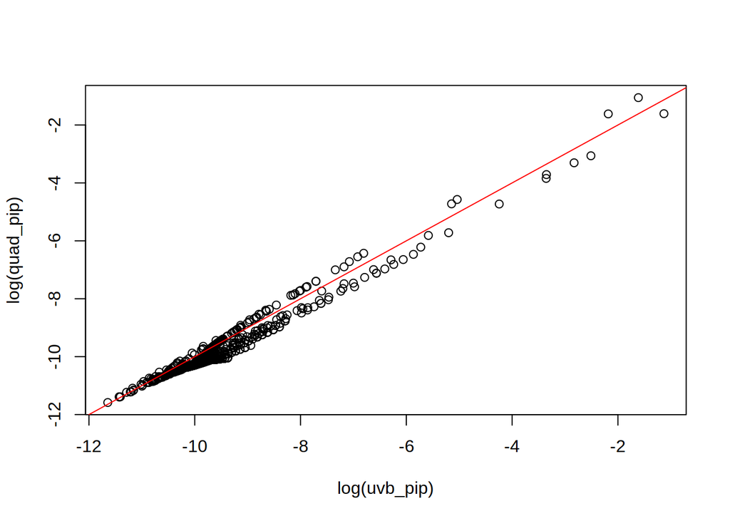

```r
uvb_pip <- fits2 %>% filter(fit_method == 'uvb_ser') %>% pull(fit) %>% {.[[1]]$alpha}
quad_pip <- fits2 %>% filter(fit_method == 'quad_ser') %>% pull(fit) %>% {.[[1]]$alpha}

plot(log(uvb_pip), log(quad_pip)); abline(0, 1, col='red')
```

If we look at the log BFs for each variable we see that VB BFs are smaller– also there is a “fork”. The variational BF is a better approximation for some features than others. In earlier simulations (link?) it appeared the univariate VB bound was comparably tight across a wide range of plausible settings of the regression coefficients. I think this picture warrants exploring how tight the bound is as we also alter the variance or sparsity of the features $X$.

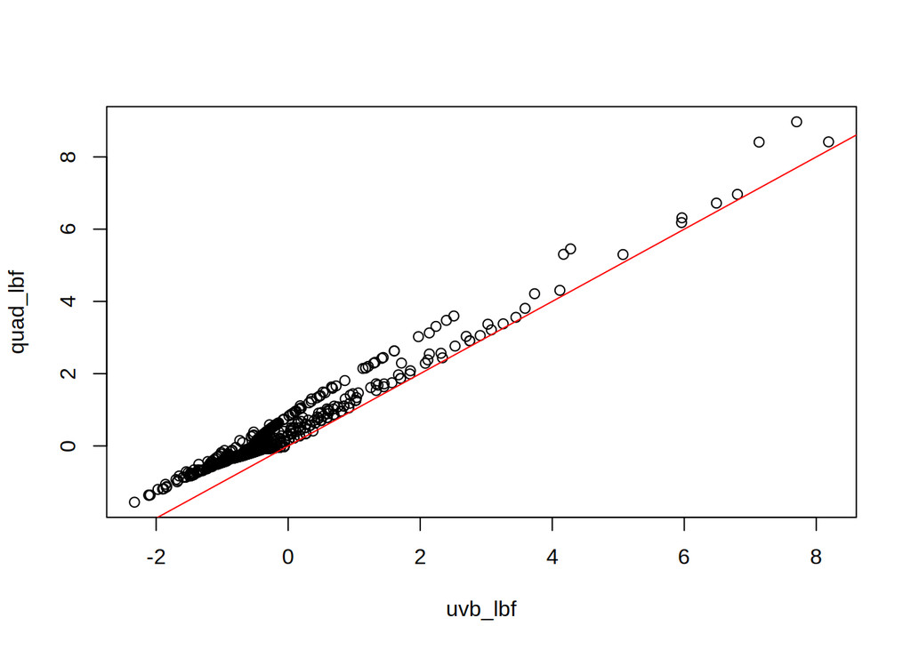

```r
uvb_lbf <- fits2 %>% filter(fit_method == 'uvb_ser') %>% pull(fit) %>% {.[[1]]$lbf}
quad_lbf <- fits2 %>% filter(fit_method == 'quad_ser') %>% pull(fit) %>% {.[[1]]$lbf}

plot(uvb_lbf, quad_lbf); abline(0, 1, col='red')
```

### 0.2.2 SuSiE

The results of applying SuSiE to the problem are summarized below. Ultimately, our alternative approaches for logistic SuSiE doesn’t give a reasonable solution here.

- Linear SuSie: returns a bunch of singleton credible sets. Many of them are among the top marginally enriched gene sets (TODO: show marginal LBF for the top feature in each gene set)
- BinSuSiE: extremely wide credible sets across all components.
- BinSuSiE2: we estimate the prior effect variance in each component $\sigma^2_l$, we fit the null model
- IBSS2m: `L5` captures the 3rd strongest marginal enrichment. All of the other components also put the most posterior mass on the same feature. Interestingly, they all have positive lbf (supporting the presence of an effect). Still the credible sets are extremely wide, containing most of the gene sets.
- IBSS-UVB: the top marginally enriched feature has the largest PIP, but the log BFs are near 0, and the credible sets are huge.

```r
# SuSiE
print_cs_tbl('linear_susie_L10')
```

```
## # A tibble: 10 × 5
##     size top_feaure top_feature_alpha   lbf L
##    <dbl>      <int>             <dbl> <dbl> <chr>
##  1     1          4             0.993 16.0  L1
##  2     1         20             1.00  10.9  L2
##  3     1         91             0.999  7.54 L3
##  4     1          1             0.980 13.2  L4
##  5     1          5             0.983 11.2  L5
##  6     1         15             0.979  4.59 L6
##  7     9         35             0.891  2.93 L7
##  8     1          7             0.988  4.87 L8
##  9    21         38             0.361  2.75 L9
## 10   257         69             0.163  1.23 L10
```

```r
print_cs_tbl('binsusie_L10')
```

```
## # A tibble: 10 × 5
##     size top_feaure top_feature_alpha    lbf L
##    <dbl>      <int>             <dbl>  <dbl> <chr>
##  1  1174          4            0.0162 -0.431 L1
##  2  1174          4            0.0162 -0.431 L2
##  3  1174          4            0.0162 -0.431 L3
##  4  1174          4            0.0162 -0.431 L4
##  5  1174          4            0.0162 -0.431 L5
##  6  1174          4            0.0162 -0.431 L6
##  7  1174          4            0.0162 -0.431 L7
##  8  1174          4            0.0161 -0.431 L8
##  9  1174          4            0.0161 -0.431 L9
## 10  1174          4            0.0161 -0.431 L10
```

```r
print_cs_tbl('binsusie2_L10')
```

```
## # A tibble: 10 × 5
##     size top_feaure top_feature_alpha   lbf L
##    <dbl>      <int>             <dbl> <dbl> <chr>
##  1  1260          3          0.000995     0 L1
##  2  1260          3          0.000995     0 L2
##  3  1260          3          0.000995     0 L3
##  4  1260          3          0.000995     0 L4
##  5  1260          3          0.000995     0 L5
##  6  1260          3          0.000995     0 L6
##  7  1260          3          0.000995     0 L7
##  8  1260          3          0.000995     0 L8
##  9  1260          3          0.000995     0 L9
## 10  1260          3          0.000995     0 L10
```

```r
print_cs_tbl('ibss2m_L10')
```

```
## # A tibble: 10 × 5
##     size top_feaure top_feature_alpha   lbf L
##    <dbl>      <int>             <dbl> <dbl> <chr>
##  1   974          3             0.336 0.930 L1
##  2   913          3             0.411 1.14  L2
##  3   964          3             0.356 0.968 L3
##  4   947          3             0.378 1.03  L4
##  5     1          3             0.983 9.95  L5
##  6   974          3             0.347 0.934 L6
##  7  1000          3             0.301 0.829 L7
##  8   985          3             0.330 0.892 L8
##  9   966          3             0.358 0.962 L9
## 10   974          3             0.346 0.934 L10
```

```r
print_cs_tbl('ibss_uvb_L10')
```

```
## # A tibble: 10 × 5
##     size top_feaure top_feature_alpha      lbf L
##    <dbl>      <int>             <dbl>    <dbl> <chr>
##  1  1136          1            0.0387 -0.0100  L1
##  2  1136          1            0.0388 -0.00995 L2
##  3  1136          1            0.0388 -0.00996 L3
##  4  1136          1            0.0387 -0.0100  L4
##  5  1136          1            0.0385 -0.0102  L5
##  6  1136          1            0.0384 -0.0103  L6
##  7  1136          1            0.0383 -0.0104  L7
##  8  1136          1            0.0383 -0.0104  L8
##  9  1136          1            0.0383 -0.0104  L9
## 10  1136          1            0.0384 -0.0103  L10
```

## 0.3 Top 500 Gene Sets

```r
fits <- tar_read(yusha_fits500)
```

```
## unable to deduce timezone name from 'America/Chicago'
```

```r
fits %>%
    mutate(converged = if_else(is.null(fit$converged), NA, fit$converged[1]))
```

```
## # A tibble: 11 × 6
## # Rowwise:
##    fit_method       fit_fun          fit_args     fit_sym fit          converged
##    <chr>            <chr>            <list>       <list>  <list>       <lgl>
##  1 vb_ser           fit_bin_ser      <list [0]>   <sym>   <named list> NA
##  2 uvb_ser          fit_uvb_ser      <list [0]>   <sym>   <named list> NA
##  3 glm_ser          fit_glm_ser      <list [0]>   <sym>   <named list> NA
##  4 linear_ser       fit_linear_susie <named list> <sym>   <susie>      TRUE
##  5 quad_ser         fit_quad_ser     <named list> <sym>   <named list> NA
##  6 linear_susie_L10 fit_linear_susie <named list> <sym>   <susie>      TRUE
##  7 binsusie_L10     fit_binsusie_wr… <named list> <sym>   <binsusie>   NA
##  8 binsusie2_L10    fit_binsusie_wr… <named list> <sym>   <binsusie>   NA
##  9 ibss2m_L10       ibss2m_jax_nosp… <named list> <sym>   <named list> NA
## 10 ibss_uvb_L10     fit_ibss_uvb     <named list> <sym>   <named list> TRUE
## 11 ibss_vb_L10      fit_ibss_vb      <named list> <sym>   <named list> TRUE
```

```r
fits2 <- fits %>%
  filter(fit_method != 'linear_ser') %>%
  mutate(lbf = list(get_lbfs(fit_method, fit))) %>%
  mutate(cs = list(logisticsusie:::get_all_cs2(fit$alpha))) %>%
  mutate(cs_tbl = list(logisticsusie:::cs_tbl2(fit$alpha)))
```

### 0.3.1 SERs

The Naive VB SER puts all it’s mass on the 33rd most marginally enriched feature, and has an extremely small BF. We know there are several strong enrichments in this example, highlighting how weak the VB bound is when we are forced to optimize the bound over all features jointly/on average.

Similar to when we looked at all gene sets, we see that UVB-SER gives a log BF closest to the exact result, while GLM-SER dramatically overeseimtates the log BF.

```r
# SERs
print_cs_tbl('vb_ser')
```

```
## # A tibble: 1 × 5
##    size top_feaure top_feature_alpha   lbf L
##   <dbl>      <int>             <dbl> <dbl> <chr>
## 1     1         33              1.00 -4.08 L1
```

```r
print_cs_tbl('uvb_ser')
```

```
## # A tibble: 1 × 5
##    size top_feaure top_feature_alpha   lbf L
##   <dbl>      <int>             <dbl> <dbl> <chr>
## 1    29          1             0.339  3.05 L1
```

```r
print_cs_tbl('glm_ser')
```

```
## # A tibble: 1 × 5
##    size top_feaure top_feature_alpha   lbf L
##   <dbl>      <int>             <dbl> <dbl> <chr>
## 1     4          1             0.704  7.78 L1
```

```r
print_cs_tbl('quad_ser')
```

```
## # A tibble: 1 × 5
##    size top_feaure top_feature_alpha   lbf L
##   <dbl>      <int>             <dbl> <dbl> <chr>
## 1    18          3             0.360  3.78 L1
```

Fairly good agreement between the UVB-SER PIPs and the quadrature PIPs.

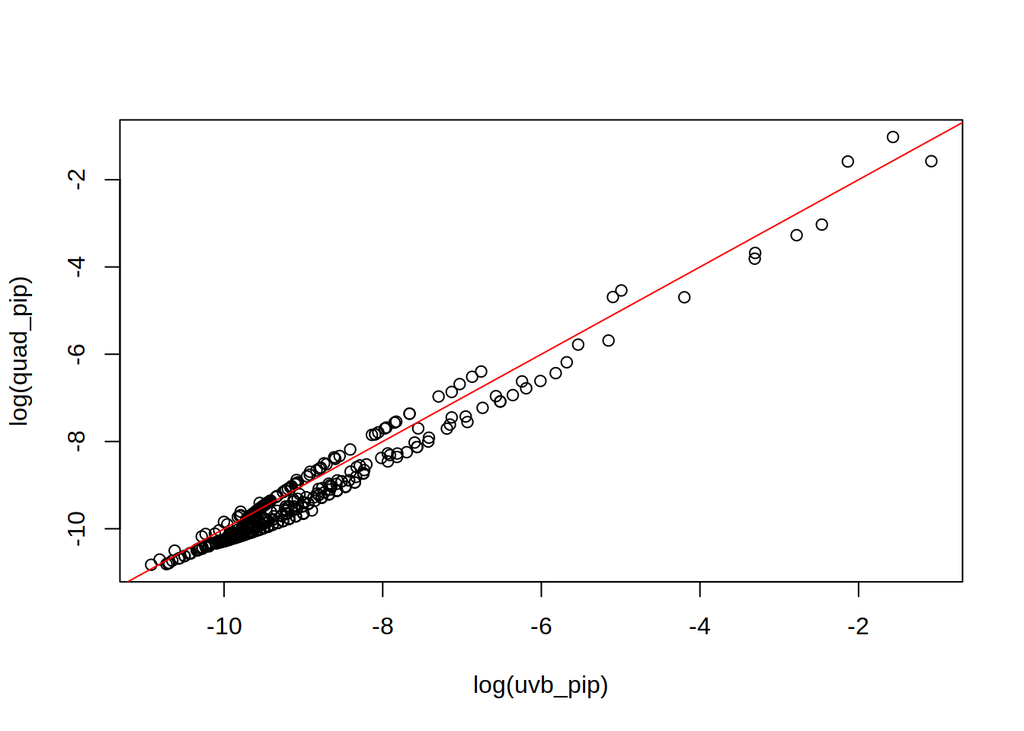

```r
uvb_pip <- fits2 %>% filter(fit_method == 'uvb_ser') %>% pull(fit) %>% {.[[1]]$alpha}
quad_pip <- fits2 %>% filter(fit_method == 'quad_ser') %>% pull(fit) %>% {.[[1]]$alpha}

plot(log(uvb_pip), log(quad_pip)); abline(0, 1, col='red')
```

If we look at the log BFs for each variable we see that VB BFs are smaller– also there is a “fork”. The variational BF is a better approximation for some features than others. In earlier simulations (link?) it appeared the univariate VB bound was comparably tight across a wide range of plausible settings of the regression coefficients. I think this picture warrants exploring how tight the bound is as we also alter the variance or sparsity of the features $X$.

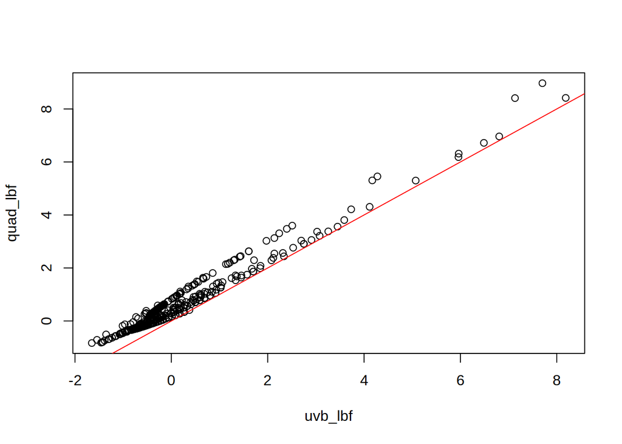

```r
uvb_lbf <- fits2 %>% filter(fit_method == 'uvb_ser') %>% pull(fit) %>% {.[[1]]$lbf}
quad_lbf <- fits2 %>% filter(fit_method == 'quad_ser') %>% pull(fit) %>% {.[[1]]$lbf}

plot(uvb_lbf, quad_lbf); abline(0, 1, col='red')
```

### 0.3.2 SuSiEs

Even when filtering to a smaller set of gene sets, all approximations for logistic SuSiE stuggle:

```r
# SuSiE
print_cs_tbl('linear_susie_L10')
```

```
## # A tibble: 10 × 5
##     size top_feaure top_feature_alpha   lbf L
##    <dbl>      <int>             <dbl> <dbl> <chr>
##  1     1          4             0.993 16.9  L1
##  2     1         20             1.00  11.9  L2
##  3     1         91             1.00   8.52 L3
##  4     1          1             0.980 13.9  L4
##  5     1          5             0.983 12.2  L5
##  6     1         15             0.983  5.54 L6
##  7     6         35             0.906  3.89 L7
##  8     1          7             0.992  5.86 L8
##  9    17         38             0.370  3.71 L9
## 10    36         69             0.174  2.16 L10
```

```r
print_cs_tbl('binsusie_L10')
```

```
## # A tibble: 10 × 5
##     size top_feaure top_feature_alpha    lbf L
##    <dbl>      <int>             <dbl>  <dbl> <chr>
##  1   436          4            0.0258 -0.326 L1
##  2   436          4            0.0259 -0.326 L2
##  3   436          4            0.0259 -0.326 L3
##  4   436          4            0.0258 -0.326 L4
##  5   436          4            0.0258 -0.326 L5
##  6   436          4            0.0258 -0.326 L6
##  7   436          4            0.0258 -0.326 L7
##  8   436          4            0.0258 -0.326 L8
##  9   436          4            0.0258 -0.326 L9
## 10   436          4            0.0258 -0.326 L10
```

```r
print_cs_tbl('binsusie2_L10')
```

```
## # A tibble: 10 × 5
##     size top_feaure top_feature_alpha      lbf L
##    <dbl>      <int>             <dbl>    <dbl> <chr>
##  1   472          1           0.00347 -0.00511 L1
##  2   472          1           0.00348 -0.00515 L2
##  3   472          1           0.00348 -0.00515 L3
##  4   472          1           0.00348 -0.00515 L4
##  5   472          1           0.00348 -0.00515 L5
##  6   472          1           0.00348 -0.00515 L6
##  7   472          1           0.00348 -0.00515 L7
##  8   472          1           0.00348 -0.00515 L8
##  9   472          1           0.00348 -0.00515 L9
## 10   472          1           0.00348 -0.00515 L10
```

```r
print_cs_tbl('ibss2m_L10')
```

```
## # A tibble: 10 × 5
##     size top_feaure top_feature_alpha   lbf L
##    <dbl>      <int>             <dbl> <dbl> <chr>
##  1   217          1             0.554  1.97 L1
##  2   282          3             0.469  1.62 L2
##  3   359          3             0.260  1.04 L3
##  4   349          3             0.303  1.13 L4
##  5   328          3             0.366  1.30 L5
##  6   342          3             0.323  1.19 L6
##  7   304          3             0.414  1.48 L7
##  8   351          3             0.294  1.12 L8
##  9     1          3             0.977  9.61 L9
## 10   322          3             0.385  1.35 L10
```

```r
print_cs_tbl('ibss_uvb_L10')
```

```
## # A tibble: 10 × 5
##     size top_feaure top_feature_alpha   lbf L
##    <dbl>      <int>             <dbl> <dbl> <chr>
##  1   418          1            0.0435 0.263 L1
##  2   418          1            0.0436 0.263 L2
##  3   418          1            0.0437 0.263 L3
##  4   418          1            0.0437 0.263 L4
##  5   418          1            0.0436 0.263 L5
##  6   418          1            0.0435 0.263 L6
##  7   418          1            0.0433 0.263 L7
##  8   418          1            0.0433 0.263 L8
##  9   418          1            0.0432 0.263 L9
## 10   418          1            0.0433 0.263 L10
```